# Supervised Learning - Foundations Project: ReCell

```python
# initial list of columns
predictors = x_train.copy()
cols = predictors.columns.tolist()

# setting an initial max p-value
max_p_value = 1

while len(cols) > 0:
    # defining the train set
    x_train_aux = predictors[cols]

    # fitting the model
    model = sm.OLS(y_train, x_train_aux).fit()

    # getting the p-values and the maximum p-value
    p_values = model.pvalues
    max_p_value = max(p_values)

    # name of the variable with maximum p-value
    feature_with_p_max = p_values.idxmax()

    if max_p_value > 0.05:
        cols.remove(feature_with_p_max)
    else:
        break

selected_features = cols
print(selected_features)
```

[output not shown]

```python
x_train2 = x_train[selected_features]
x_test2 = x_test[selected_features]
```

```python
olsmod2 = sm.OLS(y_train, x_train2).fit()
print(olsmod2.summary())
```

```
                              OLS Regression Results
=================================================================================
Dep. Variable:     normalized_used_price   R-squared:                       0.847
Model:                               OLS   Adj. R-squared:                  0.846
Method:                    Least Squares   F-statistic:                     509.9
Date:                   Fri, 09 Dec 2022   Prob (F-statistic):               0.00
Time:                           15:30:56   Log-Likelihood:                 142.48
No. Observations:                   2417   AIC:                            -231.0
Df Residuals:                       2390   BIC:                            -74.61
Df Model:                             26
Covariance Type:               nonrobust
========================================================================================
                           coef    std err          t      P>|t|      [0.025      0.975]
----------------------------------------------------------------------------------------
const                    1.7543      0.059     29.537      0.000       1.638       1.871
screen_size              0.0240      0.003      7.635      0.000       0.018       0.030
selfie_camera_mp         0.0140      0.001     13.088      0.000       0.012       0.016
int_memory               0.0001   6.77e-05      2.023      0.043    4.17e-06       0.000
ram                      0.0182      0.004      4.104      0.000       0.009       0.027
battery              -1.493e-05   7.05e-06     -2.118      0.034   -2.87e-05   -1.11e-06
weight                   0.0011      0.000      8.331      0.000       0.001       0.001
normalized_new_price     0.4031      0.011     35.417      0.000       0.381       0.425
phone_age               -0.0157      0.004     -4.258      0.000      -0.023      -0.008
brand_name_Nokia         0.0909      0.031      2.938      0.003       0.030       0.152
brand_name_Samsung      -0.0356      0.016     -2.199      0.028      -0.067      -0.004
brand_name_Xiaomi        0.0690      0.025      2.718      0.007       0.019       0.119
4g_yes                   0.0495      0.015      3.291      0.001       0.020       0.079
main_camera_mp_8.0      -0.1172      0.014     -8.636      0.000      -0.144      -0.091
main_camera_mp_5.0      -0.1937      0.018    -11.056      0.000      -0.228      -0.159
main_camera_mp_3.15     -0.2646      0.030     -8.716      0.000      -0.324      -0.205
main_camera_mp_2.0      -0.2889      0.027    -10.711      0.000      -0.342      -0.236
main_camera_mp_16.0      0.1044      0.024      4.360      0.000       0.057       0.151
main_camera_mp_0.3      -0.4966      0.040    -12.287      0.000      -0.576      -0.417
main_camera_mp_48.0      0.2915      0.115      2.529      0.012       0.065       0.518
main_camera_mp_1.3      -0.5172      0.062     -8.331      0.000      -0.639      -0.395
main_camera_mp_0.08     -0.4826      0.231     -2.086      0.037      -0.936      -0.029
main_camera_mp_23.0      0.2392      0.067      3.581      0.000       0.108       0.370
main_camera_mp_4.0      -0.3089      0.094     -3.271      0.001      -0.494      -0.124
main_camera_mp_10.0     -0.2386      0.116     -2.060      0.040      -0.466      -0.011
main_camera_mp_6.7      -0.3082      0.120     -2.564      0.010      -0.544      -0.072
main_camera_mp_8.1      -0.2458      0.116     -2.113      0.035      -0.474      -0.018
==============================================================================
Omnibus:                      208.965   Durbin-Watson:                   1.911
Prob(Omnibus):                  0.000   Jarque-Bera (JB):              394.419
Skew:                          -0.586   Prob(JB):                     2.25e-86
Kurtosis:                       4.594   Cond. No.                     1.69e+05
==============================================================================

Notes:
[1] Standard Errors assume that the covariance matrix of the errors is correctly specified.
[2] The condition number is large, 1.69e+05. This might indicate that there are
strong multicollinearity or other numerical problems.
```

```python
# checking model performance on train set (seen 70% data)
print("Training Performance\n")
olsmod2_train_perf = model_performance_regression(olsmod2, x_train2, y_train)
olsmod2_train_perf
```

```
Training Performance
```

|  | RMSE | MAE | R-squared | Adj. R-squared | MAPE |
| --- | --- | --- | --- | --- | --- |
| 0 | 0.22812 | 0.179195 | 0.847258 | 0.845532 | 4.289722 |

```python
# checking model performance on test set (seen 30% data)
print("Test Performance\n")
olsmod2_test_perf = model_performance_regression(olsmod2, x_test2, y_test)
olsmod2_test_perf
```

```
Test Performance
```

|  | RMSE | MAE | R-squared | Adj. R-squared | MAPE |
| --- | --- | --- | --- | --- | --- |
| 0 | 0.238456 | 0.184816 | 0.842349 | 0.83813 | 4.488782 |

```python
# let us create a dataframe with actual, fitted and residual values
df_pred = pd.DataFrame()

df_pred["Actual Values"] = y_train  # actual values
df_pred["Fitted Values"] = olsmod2.fittedvalues  # predicted values
df_pred["Residuals"] = olsmod2.resid  # residuals

df_pred.head()
```

|  | Actual Values | Fitted Values | Residuals |
| --- | --- | --- | --- |
| 3026 | 4.087488 | 3.873294 | 0.214194 |
| 1525 | 4.448399 | 4.597455 | -0.149055 |
| 1128 | 4.315353 | 4.303790 | 0.011563 |
| 3003 | 4.282068 | 4.209339 | 0.072729 |
| 2907 | 4.456438 | 4.484329 | -0.027891 |

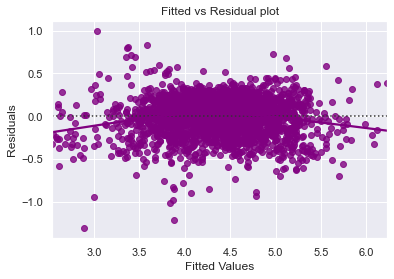

```python
# let's plot the fitted values vs residuals

sns.residplot(
    data=df_pred, x="Fitted Values", y="Residuals", color="purple", lowess=True
)
plt.xlabel("Fitted Values")
plt.ylabel("Residuals")
plt.title("Fitted vs Residual plot")
plt.show()
```

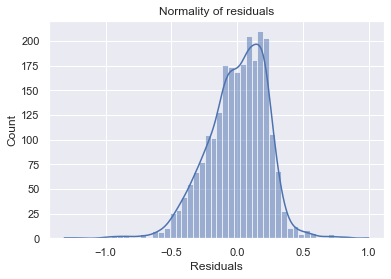

```python
sns.histplot(data=df_pred, x="Residuals", kde=True)
plt.title("Normality of residuals")
plt.show()
```

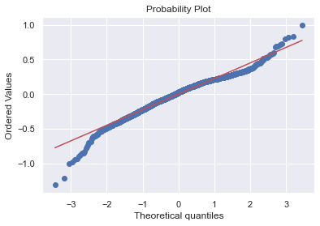

```python
import pylab
import scipy.stats as stats

stats.probplot(df_pred["Residuals"], dist="norm", plot=pylab)
plt.show()
```

- The residuals more or less follow a straight line except for the tails.

```python
stats.shapiro(df_pred["Residuals"])
```

```
ShapiroResult(statistic=0.9729299545288086, pvalue=5.528368323841178e-21)
```

Since p-value < 0.05, the residuals are not normal as per the Shapiro-Wilk test. Strictly speaking, the residuals are not normal.However, as an approximation, we can accept this distribution as close to being normal.

```python
import statsmodels.stats.api as sms
from statsmodels.compat import lzip

name = ["F statistic", "p-value"]
test = sms.het_goldfeldquandt(df_pred["Residuals"], x_train2)
lzip(name, test)
```

```
[('F statistic', 1.0621029651017095), ('p-value', 0.15023014071062937)]
```

Since p-value > 0.05, we can say that the residuals are homoscedastic. So, this assumption is satisfied.

```python
# predictions on the test set
pred = olsmod2.predict(x_test2)

df_pred_test = pd.DataFrame({"Actual": y_test, "Predicted": pred})
df_pred_test.sample(10, random_state=1)
```

|  | Actual | Predicted |
| --- | --- | --- |
| 1995 | 4.566741 | 4.437539 |
| 2341 | 3.696103 | 3.982614 |
| 1913 | 3.592093 | 3.702040 |
| 688 | 4.306495 | 4.134388 |
| 650 | 4.522115 | 5.145306 |
| 2291 | 4.259294 | 4.411313 |
| 40 | 4.997685 | 5.458849 |
| 1884 | 3.875359 | 4.066433 |
| 2538 | 4.206631 | 4.006378 |
| 45 | 5.380450 | 5.270153 |

## Final Model

```python
x_train_final = x_train2.copy()
x_test_final = x_test2.copy()
```

```python
olsmodel_final = sm.OLS(y_train, x_train_final).fit()
print(olsmodel_final.summary())
```

```
                              OLS Regression Results
=================================================================================
Dep. Variable:     normalized_used_price   R-squared:                       0.847
Model:                               OLS   Adj. R-squared:                  0.846
Method:                    Least Squares   F-statistic:                     509.9
Date:                   Fri, 09 Dec 2022   Prob (F-statistic):               0.00
Time:                           15:30:58   Log-Likelihood:                 142.48
No. Observations:                   2417   AIC:                            -231.0
Df Residuals:                       2390   BIC:                            -74.61
Df Model:                             26
Covariance Type:               nonrobust
========================================================================================
                           coef    std err          t      P>|t|      [0.025      0.975]
----------------------------------------------------------------------------------------
const                    1.7543      0.059     29.537      0.000       1.638       1.871
screen_size              0.0240      0.003      7.635      0.000       0.018       0.030
selfie_camera_mp         0.0140      0.001     13.088      0.000       0.012       0.016
int_memory               0.0001   6.77e-05      2.023      0.043    4.17e-06       0.000
ram                      0.0182      0.004      4.104      0.000       0.009       0.027
battery              -1.493e-05   7.05e-06     -2.118      0.034   -2.87e-05   -1.11e-06
weight                   0.0011      0.000      8.331      0.000       0.001       0.001
normalized_new_price     0.4031      0.011     35.417      0.000       0.381       0.425
phone_age               -0.0157      0.004     -4.258      0.000      -0.023      -0.008
brand_name_Nokia         0.0909      0.031      2.938      0.003       0.030       0.152
brand_name_Samsung      -0.0356      0.016     -2.199      0.028      -0.067      -0.004
brand_name_Xiaomi        0.0690      0.025      2.718      0.007       0.019       0.119
4g_yes                   0.0495      0.015      3.291      0.001       0.020       0.079
main_camera_mp_8.0      -0.1172      0.014     -8.636      0.000      -0.144      -0.091
main_camera_mp_5.0      -0.1937      0.018    -11.056      0.000      -0.228      -0.159
main_camera_mp_3.15     -0.2646      0.030     -8.716      0.000      -0.324      -0.205
main_camera_mp_2.0      -0.2889      0.027    -10.711      0.000      -0.342      -0.236
main_camera_mp_16.0      0.1044      0.024      4.360      0.000       0.057       0.151
main_camera_mp_0.3      -0.4966      0.040    -12.287      0.000      -0.576      -0.417
main_camera_mp_48.0      0.2915      0.115      2.529      0.012       0.065       0.518
main_camera_mp_1.3      -0.5172      0.062     -8.331      0.000      -0.639      -0.395
main_camera_mp_0.08     -0.4826      0.231     -2.086      0.037      -0.936      -0.029
main_camera_mp_23.0      0.2392      0.067      3.581      0.000       0.108       0.370
main_camera_mp_4.0      -0.3089      0.094     -3.271      0.001      -0.494      -0.124
main_camera_mp_10.0     -0.2386      0.116     -2.060      0.040      -0.466      -0.011
main_camera_mp_6.7      -0.3082      0.120     -2.564      0.010      -0.544      -0.072
main_camera_mp_8.1      -0.2458      0.116     -2.113      0.035      -0.474      -0.018
==============================================================================
Omnibus:                      208.965   Durbin-Watson:                   1.911
Prob(Omnibus):                  0.000   Jarque-Bera (JB):              394.419
Skew:                          -0.586   Prob(JB):                     2.25e-86
Kurtosis:                       4.594   Cond. No.                     1.69e+05
==============================================================================

Notes:
[1] Standard Errors assume that the covariance matrix of the errors is correctly specified.
[2] The condition number is large, 1.69e+05. This might indicate that there are
strong multicollinearity or other numerical problems.
```

```python
# checking model performance on train set (seen 70% data)
print("Training Performance\n")
olsmodel_final_train_perf = model_performance_regression(
    olsmodel_final, x_train_final, y_train
)
olsmodel_final_train_perf
```

```
Training Performance
```

|  | RMSE | MAE | R-squared | Adj. R-squared | MAPE |
| --- | --- | --- | --- | --- | --- |
| 0 | 0.22812 | 0.179195 | 0.847258 | 0.845532 | 4.289722 |

```python
# checking model performance on test set (seen 30% data)
print("Test Performance\n")
olsmodel_final_test_perf = model_performance_regression(
    olsmodel_final, x_test_final, y_test
)
olsmodel_final_test_perf
```

```
Test Performance
```

|  | RMSE | MAE | R-squared | Adj. R-squared | MAPE |
| --- | --- | --- | --- | --- | --- |
| 0 | 0.238456 | 0.184816 | 0.842349 | 0.83813 | 4.488782 |

## Actionable Insights and Recommendations

1. The model is able to explain roughly 85% of the variation in the data and within 4.5% of the normalized used phone price of the training data. This model is suitable for prediction and inferential purposes.
2. If the normalized new phone price increase by 1 Euro the normalized used phone price will increase by.403 Euros, all other variables held constant.
3. If the phone has 4G the normalized used phone price will increase by .0495 Euros, all other variables held constant.
4. If the main camera megapixel is greater than 16 then the main camera megapixel will increase the normalized used phone price. This is true for all megapixel values greater than 16. We seean increase of .1044 for 16, .2392 for 23, and .2915 for 48 megapixels.
5. Battery, weight, and internal memory have a very small impact on the normalized used phone price.
6. Screen size and RAM have some impact on increasing the normalized used phone price as these values are increased but the impact is less significant than the brand name. Phones that are branded Samsung tend to have a negative impact on the used phone price.Nokia has the highest increase in price at .09 units increase on normalized used phone price.